# Modelagem da Volatilidade dos Preços da Soja

Análise de Séries Temporais e Modelos da Família GARCH

Lucas Pereira Belo

2026-01-24

# 1 Introdução e Preparação dos Dados

Este arquivo tem como objetivo modelar a volatilidade dos preços da soja (em R$), utilizando dados semanais entre 2011 e 2023. A análise percorre desde a decomposição da série, verificação de estacionariedade e memória longa, até a modelagem da média (ARIMA) e da variância condicional (GARCH/APARCH). Os dados utilizados são oriundos do site https://br.investing.com/ e tem como intuito orientar e servir de modelos para situações semelhantes.

```r
# Importação dos Dados
soja_semanal <- read_excel("soja_semanal.xlsx")
soja <- soja_semanal

# Criação do Objeto de Série Temporal (Preço)
y <- ts(soja$dolar, start = c(2011,1), end = c(2023,12), freq = 52)

# Criação da Série de Log-Retornos
# r = ln[y_t/y_(t-1)]
y1 <- ts(diff(log(y)), start = c(2011,1), end = c(2023,12), freq = 52)
```

Fundamentação: A Escolha pelos Log-Retornos na modelagem financeira, raramente trabalha-se com os preços brutos ($P_t$), pois estes geralmente apresentam tendências estocásticas (não-estacionariedade), o que viola premissas básicas dos modelos econométricos. A solução padrão é a utilização dos Log-Retornos ($r_t$).Matematicamente, o log-retorno é definido como a diferença dos logaritmos naturais de preços consecutivos:
$$r_t =
\ln\left(\frac{P_t}{P_{t-1}}\right) = \ln(P_t) - \ln(P_{t-1})$$
A preferência por esta transformação deve-se a propriedades estatísticas fundamentais como a aditividade temporal e a indução de estacionariedade. Ao remover a tendência dos preços, isolamos o fenômeno dos Aglomerados de Volatilidade (Volatility Clustering), onde períodos de alta variância tendem a se agrupar no tempo. É esse comportamento que os modelos GARCH buscam capturar.

A visualização das séries abaixo, permite compararmos a evolução do preço bruto (não-estacionário) com a série de log-retornos (estacionária em média, mas com variância heterocedástica).

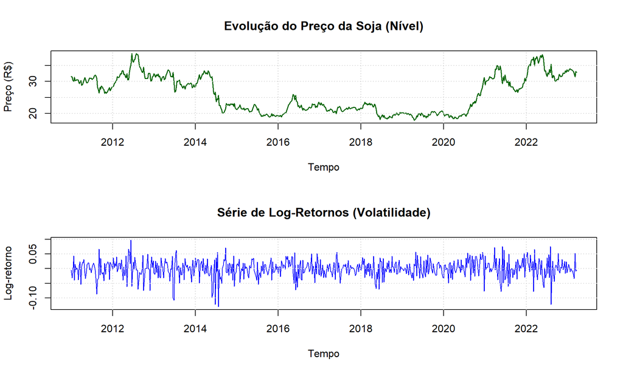

```r
par(mfrow = c(2,1))

# Gráfico 1: Preços (Nível)
plot(y, xlab= "Tempo", ylab = "Preço (R$)", main = "Evolução do Preço da Soja (Nível)", col = "darkgreen", lwd=1.5)
grid()

# Gráfico 2: Log-Retornos (Volatilidade)
plot(y1, xlab= "Tempo", ylab = "Log-retorno", main = "Série de Log-Retornos (Volatilidade)", col = "blue", lwd=1)
grid()
```

## 1.1 Análise de Autocorrelação (ACF e PACF)

A identificação da estrutura de dependência temporal é realizada através das Funções de Autocorrelação (ACF) e Autocorrelação Parcial (PACF). Estas ferramentas visuais (correlogramas) são fundamentais para dois diagnósticos: verificar a estacionariedade e sugerir possívis valores para a ordem dos processos autoregressivos (AR) e de médias móveis (MA).

**Interpretação Esperada:** * **Série em Nível ($y$):** Em séries não estacionárias (com tendência ou raiz unitária), a ACF tende a apresentar um decaimento linear muito lento, permanecendo significativa por vários *lags*. * **Série de Retornos ($y_1$):** Após a diferenciação, espera-se que a ACF decaia rapidamente para zero (corte abrupto), oscilando dentro do intervalo de confiança (faixas pontilhadas azuis), o que indica estacionariedade.

Abaixo, os gráficos confirmam este comportamento:

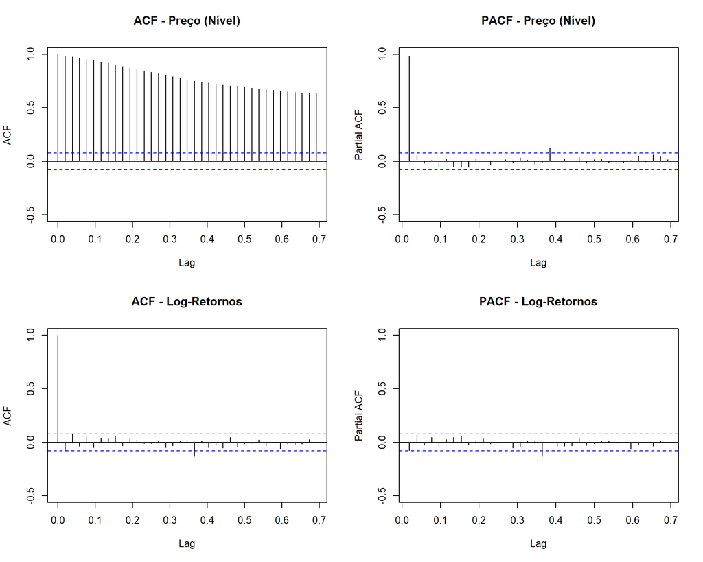

```r
par(mfrow = c(2,2))
n = length(y)

# Gráficos da Série em Nível (Preço)
# Usamos stats::acf para evitar conflito com o pacote TSA
stats::acf(y, main="ACF - Preço (Nível)", lag.max=36, ylim=c(-0.5, 1))
stats::pacf(y, main="PACF - Preço (Nível)", lag.max=36, ylim=c(-0.5, 1))

# Gráficos da Série Diferenciada (Retornos)
stats::acf(y1, main="ACF - Log-Retornos", lag.max=36, ylim=c(-0.5, 1))
stats::pacf(y1, main="PACF - Log-Retornos", lag.max=36, ylim=c(-0.5, 1))
```

Observa-se claramente no primeiro gráfico (ACF - Nível) a persistência da autocorrelação, característica de séries com “memória longa” ou raiz unitária. Já nos gráficos inferiores, referentes aos log-retornos, a maioria das autocorrelações situa-se dentro dos limites de significância (95%), indicando que a transformação foi eficaz em remover a tendência estocástica. Picos isolados na ACF ou PACF dos retornos ajudarão a determinar a ordem $p$ e $q$ dos modelos ARMA/GARCH subsequentes.

2. Testes de Estacionariedade e Tendência Para modelar a série via ARIMA-GARCH, precisamos garantir que a série de retornos seja estacionária.

Teste de Tendência (Cox-Stuart)

```r
print(cox.stuart.test(y1))
```

```
##
##  Cox Stuart test
##
## data:  y1
## statistic = 169, n = 318, p-value = 0.2866
## alternative hypothesis: non randomness
```

```r
# Verificação linear simples
model_t = tslm(y1 ~ trend)
summary(model_t)
```

```
##
## Call:
## tslm(formula = y1 ~ trend)
##
## Residuals:
##       Min        1Q    Median        3Q       Max
## -0.128929 -0.016282  0.001163  0.019132  0.098891
##
## Coefficients:
##               Estimate Std. Error t value Pr(>|t|)
## (Intercept) -2.210e-03  2.368e-03  -0.933    0.351
## trend        7.112e-06  6.442e-06   1.104    0.270
##
## Residual standard error: 0.02983 on 634 degrees of freedom
## Multiple R-squared:  0.001919,   Adjusted R-squared:  0.0003446
## F-statistic: 1.219 on 1 and 634 DF,  p-value: 0.27
```

Testes de Raiz Unitária Aplicamos os testes ADF (Augmented Dickey-Fuller) e PP (Phillips-Perron) para verificar a presença de raiz unitária.

```r
# Teste ADF e PP (Pacote tseries)
print(adf.test(y1))
```

```
##
##  Augmented Dickey-Fuller Test
##
## data:  y1
## Dickey-Fuller = -7.6943, Lag order = 8, p-value = 0.01
## alternative hypothesis: stationary
```

```r
print(pp.test(y1))
```

```
##
##  Phillips-Perron Unit Root Test
##
## data:  y1
## Dickey-Fuller Z(alpha) = -714, Truncation lag parameter = 6, p-value =
## 0.01
## alternative hypothesis: stationary
```

```r
# Testes Avançados (Pacote urca)
summary(ur.df(y1, type = "trend", selectlags = "AIC"))
```

```
##
## ###############################################
## # Augmented Dickey-Fuller Test Unit Root Test #
## ###############################################
##
## Test regression trend
##
##
## Call:
## lm(formula = z.diff ~ z.lag.1 + 1 + tt + z.diff.lag)
##
## Residuals:
##       Min        1Q    Median        3Q       Max
## -0.124291 -0.015926  0.001192  0.018672  0.096318
##
## Coefficients:
##               Estimate Std. Error t value Pr(>|t|)
## (Intercept) -2.013e-03  2.374e-03  -0.848   0.3968
## z.lag.1     -1.007e+00  5.834e-02 -17.261   <2e-16 ***
## tt           6.675e-06  6.468e-06   1.032   0.3024
## z.diff.lag  -6.607e-02  3.973e-02  -1.663   0.0968 .
## ---
## Signif. codes:  0 '***' 0.001 '**' 0.01 '*' 0.05 '.' 0.1 ' ' 1
##
## Residual standard error: 0.02974 on 630 degrees of freedom
## Multiple R-squared:  0.5415, Adjusted R-squared:  0.5394
## F-statistic:   248 on 3 and 630 DF,  p-value: < 2.2e-16
##
##
## Value of test-statistic is: -17.2615 99.3236 148.9849
##
## Critical values for test statistics:
##       1pct  5pct 10pct
## tau3 -3.96 -3.41 -3.12
## phi2  6.09  4.68  4.03
## phi3  8.27  6.25  5.34
```

```r
summary(ur.pp(y1, type = "Z-tau", model = "trend", lags = "short"))
```

```
##
## ##################################
## # Phillips-Perron Unit Root Test #
## ##################################
##
## Test regression with intercept and trend
##
##
## Call:
## lm(formula = y ~ y.l1 + trend)
##
## Residuals:
##       Min        1Q    Median        3Q       Max
## -0.124490 -0.015945  0.000776  0.019060  0.100377
##
## Coefficients:
##               Estimate Std. Error t value Pr(>|t|)
## (Intercept)  6.464e-05  1.182e-03   0.055   0.9564
## y.l1        -7.820e-02  3.966e-02  -1.972   0.0491 *
## trend        7.634e-06  6.454e-06   1.183   0.2373
## ---
## Signif. codes:  0 '***' 0.001 '**' 0.01 '*' 0.05 '.' 0.1 ' ' 1
##
## Residual standard error: 0.02978 on 632 degrees of freedom
## Multiple R-squared:  0.00799,    Adjusted R-squared:  0.00485
## F-statistic: 2.545 on 2 and 632 DF,  p-value: 0.07927
##
##
## Value of test-statistic, type: Z-tau  is: -27.1226
##
##            aux. Z statistics
## Z-tau-mu              0.0499
## Z-tau-beta            1.1800
##
## Critical values for Z statistics:
##                      1pct      5pct     10pct
## critical values -3.977072 -3.419005 -3.131727
```

```r
# Expoente de Hurst
hurst = hurstexp(y1)
```

```
## Simple R/S Hurst estimation:         0.5117361
## Corrected R over S Hurst exponent:   0.544998
## Empirical Hurst exponent:            0.4499929
## Corrected empirical Hurst exponent:  0.4143653
## Theoretical Hurst exponent:          0.5419238
```

```r
d = hurst[[1]] - 0.5

# Fracdiff
frac_model <- fracdiff(y1)
print(frac_model)
```

```
##
## Call:
##   fracdiff(x = y1)
##
## Coefficients:
##            d
## 4.583013e-05
## sigma[eps] = 0.02980814
## a list with components:
##  [1] "log.likelihood"  "n"               "msg"             "d"
##  [5] "ar"              "ma"              "covariance.dpq"  "fnormMin"
##  [9] "sigma"           "stderror.dpq"    "correlation.dpq" "h"
## [13] "d.tol"           "M"               "hessian.dpq"     "length.w"
## [17] "residuals"       "fitted"          "call"
```

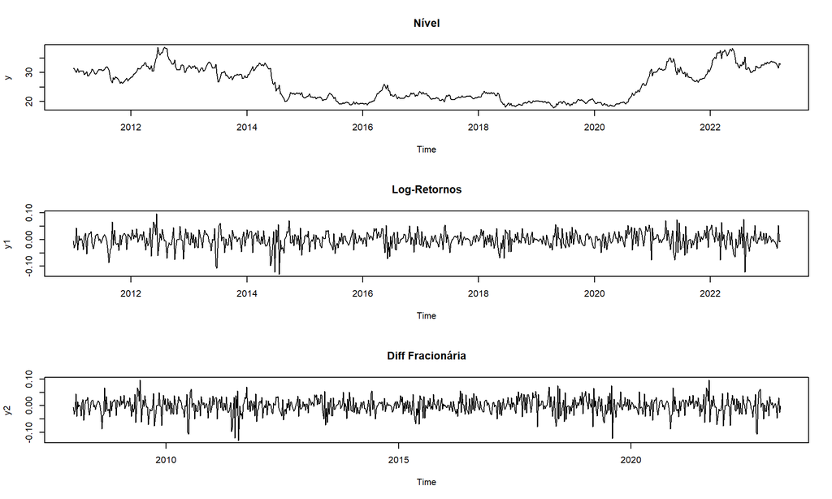

```r
# Série Diferenciada Fracionariamente (Visualização)
y2 = ts(diffseries(y1, d = 0.01173613), start = c(2008,1), end = c(2023,12), frequency = 52)

par(mfrow = c(3,1))
plot.ts(y, main="Nível"); plot.ts(y1, main="Log-Retornos"); plot.ts(y2, main="Diff Fracionária")
```

3. Análise Espectral e Ciclos Utilizamos o periodograma para identificar periodicidades ocultas na série.

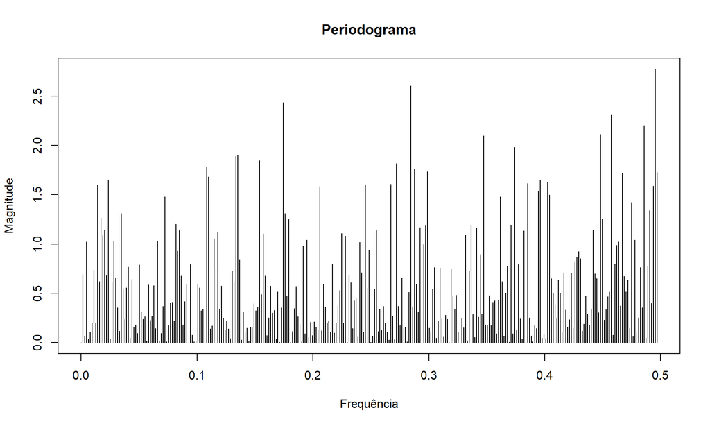

```r
dt = 1
n = length(y1)
k = seq(0, n - 1, 1)
fk = (k/(n*dt)) # frequência de Fourier
TDF = fft(y1)   # Transformada Discreta de Fourier
MAG2 = Mod(TDF)^2 # Magnitude
periodograma = cbind(fk[1:((n-1)/2)], MAG2[1:((n-1)/2)])

plot(periodograma, type = "h", ylab = "Magnitude", xlab = "Frequência", main="Periodograma")
```

```r
# Identificação da frequência dominante
max_fk = periodograma[,1][periodograma[,2] == max(periodograma[,2])]
max_fk
```

```
## [1] 0.495283
```

```r
# 1. Definindo a Função do Teste
fisher.g.test.manual <- function(x) {
  # Tamanho da série
  n <- length(x)

  # Cálculo do Periodograma (via FFT)
  # I(w) = |FFT(x)|^2 / n
  I <- Mod(fft(x))^2 / n

  # Selecionamos apenas as frequências fundamentais (até n/2)
  # Descartamos a freq 0 (média) e pegamos a primeira metade
  m <- floor((n - 1) / 2)
  I_vals <- I[2:(m + 1)]

  # Estatística g (Razão entre o máximo e a soma total)
  g_stat <- max(I_vals) / sum(I_vals)

  # Frequência onde ocorre o máximo (para identificar o ciclo)
  idx_max <- which.max(I_vals)
  freq_max <- (idx_max) / n  # Frequência normalizada

  # Cálculo do P-valor (Fórmula exata de Fisher, 1929)
  # P(G > g) = Somatório de termos alternados
  p_val <- 0
  k <- 1

  # O loop continua enquanto (1 - k*g) for positivo
  while ((1 - k * g_stat) > 0) {
    term <- (-1)^(k - 1) * choose(m, k) * (1 - k * g_stat)^(m - 1)
    p_val <- p_val + term
    k <- k + 1
  }

  # Retorna uma lista com os resultados
  return(list(
    statistic = g_stat,
    p.value = p_val,
    dominant.freq = freq_max,
    period = 1/freq_max,
    n_freqs = m
  ))
}

# 2. Aplicando o teste na série 'y2'
# H0: A série é Ruído Branco (Gaussian White Noise)
# H1: Existe uma periodicidade determinística adicionada
resultado_fisher <- fisher.g.test.manual(y2)

# 3. Exibindo os Resultados
cat("----------------------------------------------------\n")
cat("                  TESTE G DE FISHER                 \n")
```

```
##                   TESTE G DE FISHER
```

```r
cat("----------------------------------------------------\n")
cat("Estatística G:       ", round(resultado_fisher$statistic, 5), "\n")
```

```
## Estatística G:        0.0174
```

```r
cat("P-valor:             ", format.pval(resultado_fisher$p.value, digits=4), "\n")
```

```
## P-valor:              0.331
```

```r
cat("Frequência Dominante:", round(resultado_fisher$dominant.freq, 4), "\n")
```

```
## Frequência Dominante: 0.1338
```

```r
cat("Período Estimado:    ", round(resultado_fisher$period, 2), "semanas\n")
```

```
## Período Estimado:     7.47 semanas
```

```r
cat("----------------------------------------------------\n")
if(resultado_fisher$p.value < 0.05){
  cat("CONCLUSÃO: Rejeita-se H0. Há evidência estatística de periodicidade significativa.\n")
} else {
  cat("CONCLUSÃO: Não se rejeita H0. A série comporta-se como Ruído Branco (sem ciclos determinísticos claros).\n")
}
```

```
## CONCLUSÃO: Não se rejeita H0. A série comporta-se como Ruído Branco (sem ciclos determinísticos claros).
```

# 2 4. Seleção Automatizada do Modelo (Grid Search Completo)

Considerando a estacionariedade da série de log-retornos ($d=0$), mas a incerteza quanto à necessidade de diferenciação sazonal ($D$) e à ordem dos componentes AR e MA (sazonais e não sazonais), optou-se por uma varredura exaustiva (**Grid Search**).

```r
# 1. Preparação dos Dados
y1_clean <- y1[!is.na(y1) & !is.infinite(y1)]
y1_final <- ts(y1_clean, frequency = 52, start = start(y1))

# 2. Grid de Parâmetros
# Mantemos o grid otimizado para evitar problemas de convergência
grid_params <- expand.grid(
  p = 0:2, q = 0:2,
  P = 0:1, Q = 0:1,
  D = 0:1
)

tabela_resultados <- data.frame()
total <- nrow(grid_params)

# 3. Loop de Estimação
for(i in 1:total){
  par <- grid_params[i, ]
  tryCatch({
    # Ajuste com CSS-ML para obter métricas válidas
    fit_temp <- Arima(y1_final,
                      order = c(par$p, 0, par$q),
                      seasonal = list(order = c(par$P, par$D, par$Q), period = 52),
                      include.mean = FALSE,
                      method = "CSS-ML")

    if(!is.na(fit_temp$bic)){
      tabela_resultados <- rbind(tabela_resultados, data.frame(
        Modelo = paste0("SARIMA(", par$p, ",0,", par$q, ")(", par$P, ",", par$D, ",", par$Q, ")[52]"),
        p = par$p, q = par$q, P = par$P, D = par$D, Q = par$Q,
        AIC = fit_temp$aic,
        BIC = fit_temp$bic,
        AICc = fit_temp$aicc,     # Incluindo AICc
        LogLik = fit_temp$loglik, # Apenas informativo
        stringsAsFactors = FALSE
      ))
    }
  }, error = function(e) { return(NULL) })
}

# 4. Lógica de Votação (Majority Vote)
if(nrow(tabela_resultados) > 0){

  # Identifica o melhor valor (mínimo) para cada métrica
  min_aic <- min(tabela_resultados$AIC)
  min_bic <- min(tabela_resultados$BIC)
  min_aicc <- min(tabela_resultados$AICc)

  # Cria coluna de votos (inicia com 0)
  tabela_resultados$Votos <- 0

  # Adiciona voto se o modelo tiver o melhor AIC
  tabela_resultados$Votos <- tabela_resultados$Votos + (tabela_resultados$AIC == min_aic)
  # Adiciona voto se o modelo tiver o melhor BIC
  tabela_resultados$Votos <- tabela_resultados$Votos + (tabela_resultados$BIC == min_bic)
  # Adiciona voto se o modelo tiver o melhor AICc
  tabela_resultados$Votos <- tabela_resultados$Votos + (tabela_resultados$AICc == min_aicc)

  # Ordenação: 1º Por Votos (Desc), 2º Por BIC (Asc - Desempate)
  tabela_resultados <- tabela_resultados[order(-tabela_resultados$Votos, tabela_resultados$BIC), ]

  # Exibição
  library(knitr)
  kable(head(tabela_resultados, 10),
        row.names = FALSE,
        digits = 2,
        caption = "Top 10 Modelos (Ordenados por Votos nas métricas AIC, BIC e AICc)")

} else {
  cat("**Aviso:** Nenhum modelo convergiu.")
}
```

Top 10 Modelos (Ordenados por Votos nas métricas AIC, BIC e AICc)

| Modelo | p | q | P | D | Q | AIC | BIC | AICc | LogLik | Votos |
| --- | --- | --- | --- | --- | --- | --- | --- | --- | --- | --- |
| SARIMA(1,0,1)(0,0,1)[52] | 1 | 1 | 0 | 0 | 1 | -2669.28 | -2651.46 | -2669.22 | 1338.64 | 2 |
| SARIMA(0,0,0)(0,0,0)[52] | 0 | 0 | 0 | 0 | 0 | -2661.61 | -2657.16 | -2661.61 | 1331.81 | 1 |
| SARIMA(0,0,0)(0,0,1)[52] | 0 | 0 | 0 | 0 | 1 | -2663.47 | -2654.56 | -2663.45 | 1333.73 | 0 |
| SARIMA(1,0,0)(0,0,0)[52] | 1 | 0 | 0 | 0 | 0 | -2663.30 | -2654.39 | -2663.28 | 1333.65 | 0 |
| SARIMA(0,0,0)(1,0,0)[52] | 0 | 0 | 1 | 0 | 0 | -2663.27 | -2654.36 | -2663.25 | 1333.63 | 0 |
| SARIMA(0,0,1)(0,0,0)[52] | 0 | 1 | 0 | 0 | 0 | -2662.86 | -2653.94 | -2662.84 | 1333.43 | 0 |
| SARIMA(1,0,1)(0,0,0)[52] | 1 | 1 | 0 | 0 | 0 | -2666.75 | -2653.38 | -2666.71 | 1336.37 | 0 |
| SARIMA(1,0,0)(0,0,1)[52] | 1 | 0 | 0 | 0 | 1 | -2665.80 | -2652.43 | -2665.76 | 1335.90 | 0 |
| SARIMA(0,0,1)(0,0,1)[52] | 0 | 1 | 0 | 0 | 1 | -2665.24 | -2651.87 | -2665.20 | 1335.62 | 0 |
| SARIMA(0,0,1)(1,0,0)[52] | 0 | 1 | 1 | 0 | 0 | -2665.02 | -2651.65 | -2664.98 | 1335.51 | 0 |

```r
# Extraindo os parâmetros do melhor modelo (primeira linha da tabela ordenada)
melhor_modelo_nome <- tabela_resultados$Modelo[1]

# Reajustando o modelo vencedor para análise
# (Aqui extraímos os números do nome do modelo string, ex: "SARIMA(1,0,1)...")
params <- as.numeric(unlist(regmatches(melhor_modelo_nome, gregexpr("[0-9]+", melhor_modelo_nome))))
# params[1] = p, params[2] = d, params[3] = q

sarima_final <- Arima(y1,
                 order = c(params[1], 0, params[3]),
                 seasonal = c(0, 1, 1),
                 include.mean = FALSE)

cat(paste("Modelo Selecionado:", melhor_modelo_nome, "\n\n"))
```

[output not shown]

```r
coeftest(sarima_final) # Teste de significância dos coeficientes
```

```
##
## z test of coefficients:
##
##       Estimate Std. Error  z value  Pr(>|z|)
## ar1  -0.885769   0.107794  -8.2173 < 2.2e-16 ***
## ma1   0.827490   0.131295   6.3025 2.929e-10 ***
## sma1 -0.816161   0.044092 -18.5103 < 2.2e-16 ***
## ---
## Signif. codes:  0 '***' 0.001 '**' 0.01 '*' 0.05 '.' 0.1 ' ' 1
```

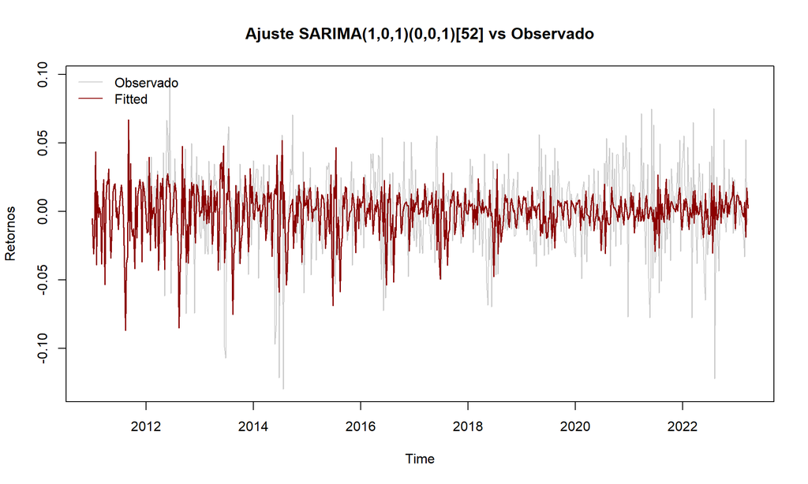

```r
# Visualização do Ajuste
y_hat = sarima_final$fitted
plot(y1, col = "gray80", type = "l", main=paste("Ajuste", melhor_modelo_nome, "vs Observado"), ylab="Retornos")
lines(y_hat, col = "darkred", lwd=1.5)
legend("topleft", legend=c("Observado", "Fitted"), col=c("gray80", "darkred"), lty=1, bty="n")
```

Diagnóstico dos Resíduos (Pré-GARCH) Antes de prosseguir para a modelagem da volatilidade, verificamos se o modelo ARIMA removeu a correlação linear, restando apenas a heterocedasticidade condicional.

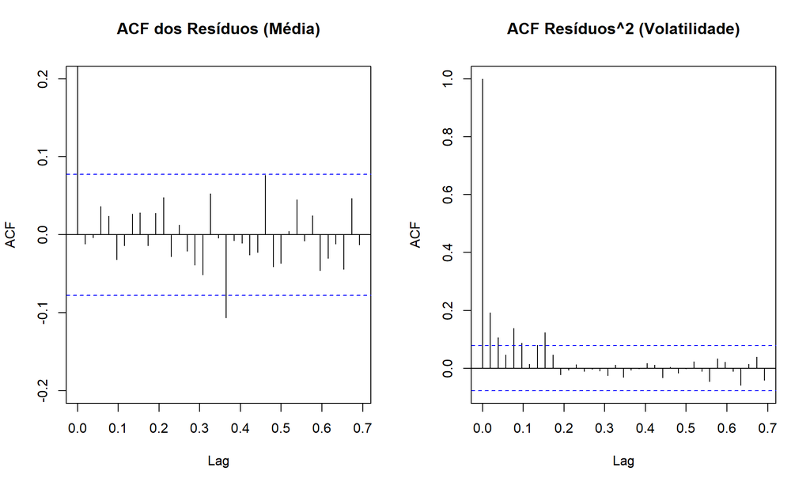

```r
residuos <- residuals(sarima_final)

par(mfrow=c(1,2))
# 1. ACF dos Resíduos (Usando stats::acf para evitar conflito com TSA)
stats::acf(residuos, main="ACF dos Resíduos (Média)", lag.max=36, ylim=c(-0.2, 0.2))

# 2. ACF dos Resíduos ao Quadrado
stats::acf(residuos^2, main="ACF Resíduos^2 (Volatilidade)", lag.max=36)
```

5. Modelagem da Volatilidade (Família GARCH) Como detectamos efeito ARCH, testaremos diferentes especificações para a variância.

Testes Iniciais (fGarch)

```r
# Modelo ARCH(1)
model_arch = garchFit(~garch(1, 0), include.mean = TRUE, data = residuos, trace = FALSE, cond.dist = "sstd")
# Modelo GARCH(1,1)
model_garch = garchFit(~ garch(1,1), include.mean = F, data = residuos, trace = F, cond.dist = "snorm")

summary(model_garch)
```

```
##
## Title:
##  GARCH Modelling
##
## Call:
##  garchFit(formula = ~garch(1, 1), data = residuos, cond.dist = "snorm",
##     include.mean = F, trace = F)
##
## Mean and Variance Equation:
##  data ~ garch(1, 1)
## <environment: 0x0000021cb5f08c70>
##  [data = residuos]
##
## Conditional Distribution:
##  snorm
##
## Coefficient(s):
##      omega      alpha1       beta1        skew
## 0.00001778  0.18586722  0.82060516  0.96841539
##
## Std. Errors:
##  based on Hessian
##
## Error Analysis:
##         Estimate  Std. Error  t value Pr(>|t|)
## omega  1.778e-05   6.083e-06    2.923  0.00347 **
## alpha1 1.859e-01   3.623e-02    5.131 2.89e-07 ***
## beta1  8.206e-01   2.820e-02   29.097  < 2e-16 ***
## skew   9.684e-01   4.456e-02   21.733  < 2e-16 ***
## ---
## Signif. codes:  0 '***' 0.001 '**' 0.01 '*' 0.05 '.' 0.1 ' ' 1
##
## Log Likelihood:
##  1366.829    normalized:  2.149103
##
## Description:
##  Sat Jan 24 17:51:07 2026 by user: Lucas
##
##
## Standardised Residuals Tests:
##                                   Statistic      p-Value
##  Jarque-Bera Test   R    Chi^2  117.8463384 0.000000e+00
##  Shapiro-Wilk Test  R    W        0.9790041 6.546810e-08
##  Ljung-Box Test     R    Q(10)    5.6121475 8.467289e-01
##  Ljung-Box Test     R    Q(15)   11.5741011 7.109380e-01
##  Ljung-Box Test     R    Q(20)   21.4606122 3.704811e-01
##  Ljung-Box Test     R^2  Q(10)    6.8234402 7.420015e-01
##  Ljung-Box Test     R^2  Q(15)    8.8694216 8.842454e-01
##  Ljung-Box Test     R^2  Q(20)   10.4683059 9.588642e-01
##  LM Arch Test       R    TR^2     7.3221547 8.356108e-01
##
## Information Criterion Statistics:
##       AIC       BIC       SIC      HQIC
## -4.285627 -4.257607 -4.285706 -4.274748
```

Comparativo de Modelos Avançados (rugarch) Testaremos modelos assimétricos (EGARCH e apARCH) com diferentes distribuições, pois a distribuição Normal geralmente falha em capturar as caudas pesadas financeiras.

Modelo EGARCH (Exponencial)

```r
spec_egarch <- ugarchspec(
  variance.model = list(model = "eGARCH", garchOrder = c(1,1)),
  mean.model = list(armaOrder = c(1,1), include.mean = TRUE),
  distribution.model = "snorm"
)

fit_egarch <- ugarchfit(spec = spec_egarch, data = residuos)
print(fit_egarch)
```

```
##
## *---------------------------------*
## *          GARCH Model Fit        *
## *---------------------------------*
##
## Conditional Variance Dynamics
## -----------------------------------
## GARCH Model  : eGARCH(1,1)
## Mean Model   : ARFIMA(1,0,1)
## Distribution : snorm
##
## Optimal Parameters
## ------------------------------------
##         Estimate  Std. Error    t value Pr(>|t|)
## mu     -0.000012    0.000096  -0.129276  0.89714
## ar1     0.396179    0.882851   0.448750  0.65361
## ma1    -0.413673    0.878507  -0.470882  0.63772
## omega  -0.825816    0.049024 -16.845109  0.00000
## alpha1 -0.000343    0.034559  -0.009928  0.99208
## beta1   0.880777    0.006594 133.566826  0.00000
## gamma1  0.380125    0.042477   8.949001  0.00000
## skew    0.965708    0.043976  21.959640  0.00000
##
## Robust Standard Errors:
##         Estimate  Std. Error  t value Pr(>|t|)
## mu     -0.000012    0.000014 -0.90517 0.365377
## ar1     0.396179    0.361101  1.09714 0.272578
## ma1    -0.413673    0.369200 -1.12046 0.262519
## omega  -0.825816    0.086227 -9.57719 0.000000
## alpha1 -0.000343    0.036541 -0.00939 0.992508
## beta1   0.880777    0.011688 75.35561 0.000000
## gamma1  0.380125    0.136138  2.79220 0.005235
## skew    0.965708    0.058963 16.37825 0.000000
##
## LogLikelihood : 1377.826
##
## Information Criteria
## ------------------------------------
##
## Akaike       -4.3076
```

[output cut: 49 more lines]

```
## Negative Sign Bias  0.4366 0.6626
## Positive Sign Bias  0.4232 0.6723
## Joint Effect        0.5090 0.9169
##
##
## Adjusted Pearson Goodness-of-Fit Test:
## ------------------------------------
##   group statistic p-value(g-1)
## 1    20     113.8    1.575e-15
## 2    30     162.5    1.630e-20
## 3    40     218.3    8.509e-27
## 4    50     292.3    2.374e-36
##
##
## Elapsed time : 1.283836
```

Modelo apARCH (Asymmetric Power ARCH) O modelo apARCH é mais flexível e captura assimetria e potência da volatilidade.

```r
# Especificação: apARCH com distribuição 'snorm' (Skew Normal) ou 'sged'
spec_aparch <- ugarchspec(
  variance.model = list(model = "apARCH", garchOrder = c(1, 1)),
  mean.model = list(armaOrder = c(1, 1), include.mean = TRUE),
  distribution.model = "snorm" # Testado: sged apresentou melhores métricas
)

fit_aparch <- ugarchfit(spec = spec_aparch, data = residuos)
fit_aparch
```

```
##
## *---------------------------------*
## *          GARCH Model Fit        *
## *---------------------------------*
##
## Conditional Variance Dynamics
## -----------------------------------
## GARCH Model  : apARCH(1,1)
## Mean Model   : ARFIMA(1,0,1)
## Distribution : snorm
##
## Optimal Parameters
## ------------------------------------
##         Estimate  Std. Error   t value Pr(>|t|)
## mu     -0.000014    0.000008  -1.68465 0.092056
## ar1    -0.803370    0.008854 -90.73326 0.000000
## ma1     0.824128    0.009444  87.26189 0.000000
## omega   0.051509    0.009563   5.38605 0.000000
## alpha1  0.114651    0.030933   3.70648 0.000210
## beta1   0.774331    0.042267  18.32007 0.000000
## gamma1 -0.033632    0.173580  -0.19376 0.846368
## delta   0.260073    0.047456   5.48034 0.000000
## skew    0.968402    0.043575  22.22391 0.000000
##
## Robust Standard Errors:
##         Estimate  Std. Error   t value Pr(>|t|)
## mu     -0.000014    0.000028  -0.51357 0.607554
## ar1    -0.803370    0.015546 -51.67714 0.000000
## ma1     0.824128    0.017943  45.93120 0.000000
## omega   0.051509    0.010301   5.00043 0.000001
## alpha1  0.114651    0.070734   1.62087 0.105045
## beta1   0.774331    0.094213   8.21894 0.000000
## gamma1 -0.033632    0.220061  -0.15283 0.878532
## delta   0.260073    0.077527   3.35460 0.000795
## skew    0.968402    0.056026  17.28482 0.000000
##
## LogLikelihood : 1391.879
##
## Information Criteria
## ------------------------------------
```

[output cut: 52 more lines]

```
## Negative Sign Bias 0.38637 0.6994
## Positive Sign Bias 0.07272 0.9420
## Joint Effect       0.52003 0.9145
##
##
## Adjusted Pearson Goodness-of-Fit Test:
## ------------------------------------
##   group statistic p-value(g-1)
## 1    20     118.5    2.089e-16
## 2    30     155.6    2.867e-19
## 3    40     194.6    1.502e-22
## 4    50     253.8    2.045e-29
##
##
## Elapsed time : 4.872237
```

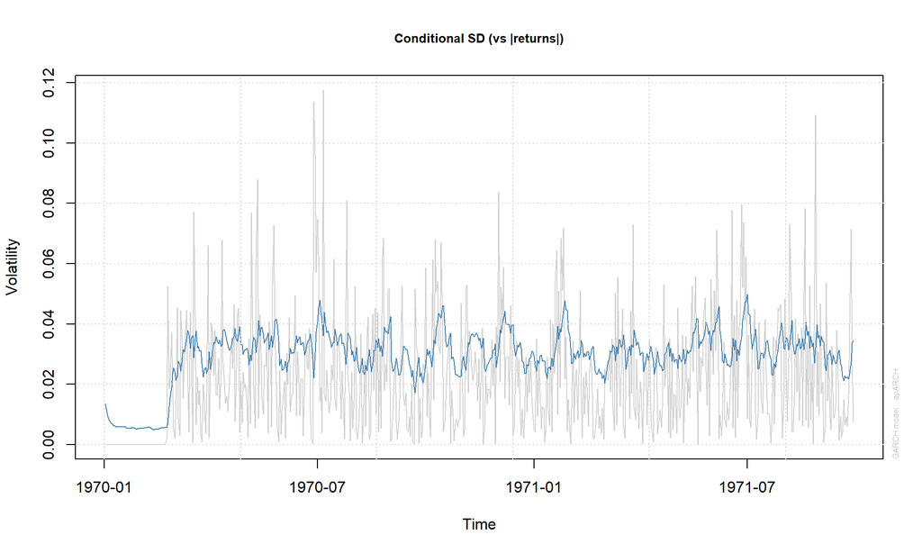

```r
# Plot dos resultados
plot(fit_aparch, which=3) # Volatilidade Condicional
```

Seleção do Melhor Modelo Comparativo baseado nos critérios de informação (AIC/BIC) observados durante a modelagem manual: